# Przygotowanie środowiska pracy

## 2. Scatter + Stem + subplots

Do dużej liczby danych rozproszonych zamiast metody plot warto skorzystać z metody scatter. Reszta parametrów nie ulega zmianie i jest bardzo podoba do tego co przed chwilą omówiliśmy.

> Źródło: https://matplotlib.org/3.3.2/gallery/lines_bars_and_markers/scatter_masked.html

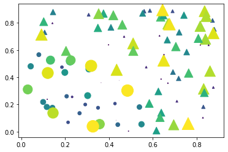

```python
import matplotlib.pyplot as plt
import numpy as np

# Fixing random state for reproducibility
np.random.seed(19680801)


N = 100
r0 = 0.6
x = 0.9 * np.random.rand(N)
y = 0.9 * np.random.rand(N)
area = (20 * np.random.rand(N))**2  # 0 to 10 point radii
c = np.sqrt(area) # kolor zależy od pola
r = np.sqrt(x ** 2 + y ** 2)
area1 = np.ma.masked_where(r < r0, area)
area2 = np.ma.masked_where(r >= r0, area)
plt.scatter(x, y, s=area1, marker='^', c=c)
plt.scatter(x, y, s=area2, marker='o', c=c)

plt.show()
```

Wykresem który łączy plot ze scatter jest stem.

```
plt.stem(x,y)
```

> **Gdzie:**
> - x - lista danych z osi X
> - y - lista danych z osi Y

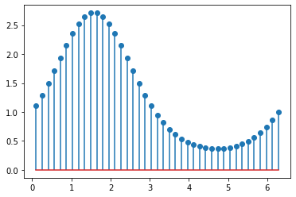

```python
import matplotlib.pyplot as plt
import numpy as np

x = np.linspace(0.1, 2 * np.pi, 41)
y = np.exp(np.sin(x))

plt.stem(x, y, use_line_collection=True)
plt.show()
```

Domyślnie program tworzy jedną figurę (tak nazywany jest poszczególny obraz w matplotlib) i będzie ją nadpisywać tak długo jak długo nie wywołamy metody **show**. Pozwala nam to zawrzeć kilka wykresów na jednym obrazie.

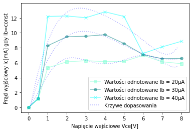

```python
#ZADANIE2
#Napiecie wyjsciowe Vce
Vce=np.array([0, 0.5, 1, 2, 3, 4, 5, 6, 7, 8])
#Prad wyjściowy Ic(mA) przy stałej wartości prądu wejściowego

Ib20=np.array([0.01, 1.15, 5.32, 6.11, 6.27, 6.14, 6.17, 6.98, 6.12, 5.87])
Ib30=np.array([0.01, 1.19, 8.28, 9.47, 9.55, 9.75, 8.57, 7.08, 6.53, 6.57])
Ib40=np.array([0.02, 1.21, 12.20, 12.26, 12.03, 12.82, 12.20, 7.24, 8.12, 8.86])

z3=np.polyfit(Vce,Ib20,6)
z4=np.polyfit(Vce,Ib30,5)
z5=np.polyfit(Vce,Ib40,6)

p_3=np.poly1d(z3)
p_4=np.poly1d(z4)
p_5=np.poly1d(z5)
xp=np.linspace(start=0.1,stop=7.8, num=100)

p3 = plt.plot(Vce,Ib20,color="aquamarine",linestyle='-',marker="s", alpha=0.5,label="Wartości odnotowane Ib = 20"+u'\u03bc'+"A")
p33 = plt.plot(xp,p_3(xp),'b:',alpha=0.3)
p4 = plt.plot(Vce,Ib30,color="teal",linestyle='-',marker="p", alpha=0.5,label="Wartości odnotowane Ib = 30"+u'\u03bc'+"A")
p44 = plt.plot(xp,p_4(xp),'b:',alpha=0.3)
p5 = plt.plot(Vce,Ib40,color="cyan",linestyle='-',marker="x", alpha=0.5,label="Wartości odnotowane Ib = 40"+u'\u03bc'+"A")
p55 = plt.plot(xp,p_5(xp),'b:',alpha=0.3,label="Krzywe dopasowania")
plt.subplots_adjust(wspace=20)
plt.legend(loc='lower right') #można dokreślić gdzie ma znajdować się legenda
plt.xlabel("Napięcie wejściowe Vce[V]")
plt.ylabel("Prąd wyjściowy Ic[mA] gdy Ib=const")
plt.show()
```

Jeżeli jednak chcemy rozbić nasze obliczenia na kilka różnych obrazów. Musimy zrozumieć koncepcje figur, osi oraz subplotów. Dotychczasowy zapis, który wykorzystywaliśmy jest tak naprawdę uproszczeniem poniższego zapisu.

```
plt.subplots(nrows=1, ncols=1)
```

> **Gdzie**:
> - nrows - ile szeregów wykresów
> - ncols - ile kolumn wykresów

Metoda ta zwraca figurę, oraz osie (lub listę osi) w których będziemy rysować wykresy.

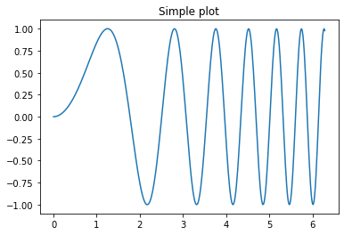

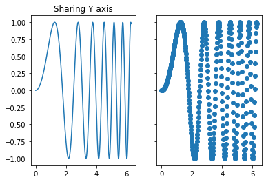

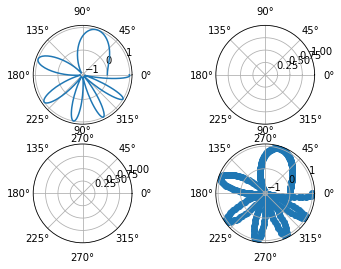

```python
import numpy as np
import matplotlib.pyplot as plt


# First create some toy data:
x = np.linspace(0, 2*np.pi, 400)
y = np.sin(x**2)

# Create just a figure and only one subplot
fig, ax = plt.subplots()
ax.plot(x, y)
ax.set_title('Simple plot') #metody wykorzystywane w osiach różnią się nazwą, zamiast plt.title mamy ax.set_title

# Create two subplots and unpack the output array immediately
f, (ax1, ax2) = plt.subplots(1, 2, sharey=True)
ax1.plot(x, y)
ax1.set_title('Sharing Y axis')
ax2.scatter(x, y)

# Create four polar axes and access them through the returned array
fig, axs = plt.subplots(2, 2, subplot_kw=dict(polar=True))
axs[0, 0].plot(x, y)
axs[1, 1].scatter(x, y)
plt.show()
```

Całkowity obraz składa się z poszczególnych obrazów (**figure**), które z kolei składają się ze składowych/osi (**axes**). Na początku, może to nastręczać dużo problemów w rozumieniu. Zapis jest też trochę utrudniony, niektóre metody nazywają się inaczej. Zachęcam do przeczytania wyjaśnienia, np. tutaj:

> https://medium.com/towards-artificial-intelligence/day-3-of-matplotlib-figure-axes-explained-in-detail-d6e98f7cd4e7

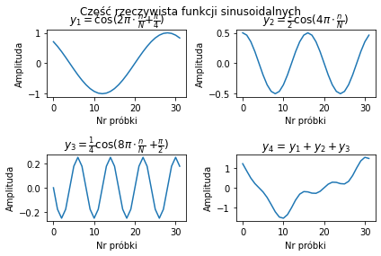

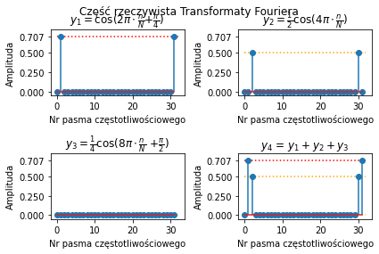

```python
import matplotlib.pyplot as plt
import numpy as np

# funkcje wykorzystane w zadaniu

def y1(N):
    n = np.arange(0,N)
    phase = np.pi/4
    y = np.cos(2 * np.pi * n/N +phase)
    return y


def y2(N):
    n = np.arange(0,N)
    phase = 0
    y = 0.5 * np.cos(4 * np.pi*n/N + phase)
    return y


def y3(N):
    n = np.arange(0,N)
    phase = np.pi / 2
    y = 0.25 * np.cos( 8 * np.pi*n/N + phase)
    return y


def y4(y1, y2, y3):
    a = y1 + y2 + y3
    return a


if __name__ == "__main__":
    N = 32  # zmienna okreslająca ilość próbek

    # Wygenerowanie funkcji
    func1 = y1(N)
    func2 = y2(N)
    func3 = y3(N)
    func4 = y4(func1, func2, func3)

    # Część rzeczywista funkcji sinusoidalnych
    plt.figure().suptitle("Część rzeczywista funkcji sinusoidalnych")
    plt.subplot(2, 2, 1)
    plt.plot(func1)
    plt.xlabel("Nr próbki")
    plt.ylabel("Amplituda")
    plt.title(r'$y_1=\cos$(2$\pi \cdot \frac{n}{N}$+$\frac{\pi}{4}$)')
    plt.subplot(2, 2, 2)
    plt.plot(func2)
    plt.xlabel("Nr próbki")
    plt.ylabel("Amplituda")
    plt.title(r'$y_2=\frac{1}{2}\cos$(4$\pi \cdot \frac{n}{N}$)')
    plt.subplot(2, 2, 3)
    plt.plot(func3)
    plt.xlabel("Nr próbki")
    plt.ylabel("Amplituda")
    plt.title(r'$y_3=\frac{1}{4}\cos$(8$\pi \cdot \frac{n}{N}$ +$\frac{\pi}{2}$)')
    plt.subplot(2, 2, 4)
    plt.title(r'$y_4$ = $y_1+y_2+y_3$')
    plt.plot(func4)
    plt.xlabel("Nr próbki")
    plt.ylabel("Amplituda")
    plt.tight_layout()
    plt.show()


    # Wyliczenia transformat Fouriera oraz innych parametrów dla każdej funkcji
    fourier1 = 2*np.fft.fft(func1)/N
    real1 = fourier1.real
    imaginary1 = fourier1.imag
    angle1 = np.angle(fourier1)
    modulus1 = np.abs(fourier1)

    fourier2 = 2*np.fft.fft(func2)/N
    real2 = fourier2.real
    imaginary2 = fourier2.imag
    angle2 = np.angle(fourier2)
    modulus2 = np.abs(fourier2)

    fourier3 = 2*np.fft.fft(func3)/N
    real3 = fourier3.real
    imaginary3 = fourier3.imag
    angle3 = np.angle(fourier3)
    modulus3 = np.abs(fourier3)

    fourier4 = 2*np.fft.fft(func4)/N
    real4 = fourier4.real
    imaginary4 = fourier4.imag
    angle4 = np.angle(fourier4)
    modulus4 = np.abs(fourier4)


    # Transformata Fouriera cz. rzeczywista
    plt.figure().suptitle("Część rzeczywista Transformaty Fouriera")
    plt.subplot(2, 2, 1)
    plt.ylim(-0.05, 0.8)
    plt.stem(real1, use_line_collection=True)
    plt.hlines(np.abs(round(real1[1], 3)), 0, 32, colors="red", linestyles="dotted")
    plt.yticks((0,0.25,0.5, np.abs(round(imaginary1[1], 3))))
    plt.xlabel("Nr pasma częstotliwościowego")
    plt.ylabel("Amplituda")
    plt.title(r'$y_1=\cos$(2$\pi \cdot \frac{n}{N}$+$\frac{\pi}{4}$)')
    plt.subplot(2, 2, 2)
    plt.ylim(-0.05, 0.8)
    plt.yticks((0,0.250, np.abs(round(real2[2], 3)),0.707))
    plt.stem(real2, use_line_collection=True)
    plt.hlines(np.abs(round(real2[2], 3)), 0, 32, colors="orange", linestyles="dotted")
    plt.xlabel("Nr pasma częstotliwościowego")
    plt.ylabel("Amplituda")
    plt.title(r'$y_2=\frac{1}{2}\cos$(4$\pi \cdot \frac{n}{N}$)')
    plt.subplot(2, 2, 3)
    plt.ylim(-0.05, 0.8)
    plt.yticks((np.abs(round(real3[4], 3)),0.250,0.50,0.707))
    plt.stem(real3, use_line_collection=True)
    plt.hlines(np.abs(round(real3[4], 3)), 0, 32, colors="gold", linestyles="dotted")
    plt.xlabel("Nr pasma częstotliwościowego")
    plt.ylabel("Amplituda")
    plt.title(r'$y_3=\frac{1}{4}\cos$(8$\pi \cdot \frac{n}{N}$ +$\frac{\pi}{2}$)')
    plt.subplot(2, 2, 4)
    plt.ylim(-0.05, 0.8)
    plt.yticks((np.abs(round(real3[4], 3)), 0.25, np.abs(round(real2[2], 3)),np.abs(round(real1[1], 3)) ))
    plt.hlines(np.abs(round(real1[1], 3)), 0, 32, colors="red", linestyles="dotted")
    plt.hlines(np.abs(round(real2[2], 3)), 0, 32, colors="orange", linestyles="dotted")
    plt.hlines(np.abs(round(real3[4], 3)), 0, 32, colors="gold", linestyles="dotted")
    plt.title(r'$y_4$ = $y_1+y_2+y_3$')
    plt.stem(real4, use_line_collection=True)
    plt.xlabel("Nr pasma częstotliwościowego")
    plt.ylabel("Amplituda")
    plt.tight_layout()
    plt.show()
```

## 3. Boxplots - wykresy pudełkowe

Do danych giełdowych bardzo często wykorzystywane są tak zwane wykresy pudełkowe, świecowe. Zakres pudełka oznacza pierwszy (dolny) i trzeci (górny) kwartyl, które odpowiednio oznaczają, że 25% i 75% danych znajduje się poniżej tych wartości. Linią przecinającą pudło oznacza się gdzie występuje mediana wartości. Zaś wąsami pudła oznacza się maksymalne odchylenia wartości (minimum i maksimum), z ograniczeniem rozmiaru wąsów dla ich czytelności.

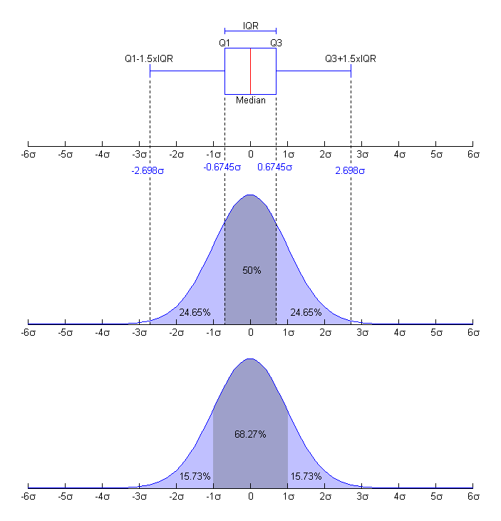

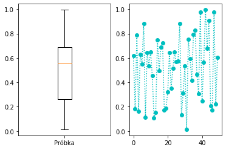

```python
import numpy as np
import matplotlib.pyplot as plt

data = np.random.rand(50)
fig, ax = plt.subplots(1,2)
ax[0].boxplot(data, labels=["Próbka"])

ax[1].plot(data, "co:")

plt.show()
```

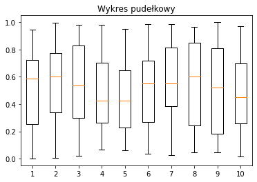

```python
import numpy as np
import matplotlib.pyplot as plt

data = np.random.rand(50,10) # wygenerowanie 10 serii po 50 wartości z przedziału 0 - 1
plt.boxplot(data)
plt.title("Wykres pudełkowy")
plt.show()
```

## 4. Barplots - wykresy kolumnowe

Kolejnym wykresem są bardzo popularne wykresy kolumnowe, wykorzystywane do porównania danych dyskretnych. Każdy słupek w wykresie ma odpowiednią wysokość, która koresponduje proporcjonalnie do wartości danej zmiennej.

```
plt.bar(x, height, width=0.8)
```

> **Gdzie**:
> - x - sekwencja koordynatów wykresu kolumnowego
> - height - sekwencja wysokości poszczególnych kolumn, lub pojedyncza wartość
> - width - szerokość kolumn (opcjonalne)

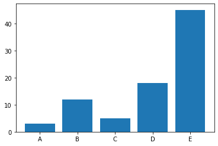

```python
import numpy as npx
import matplotlib.pyplot as plt

# Make a fake dataset:
height = [3, 12, 5, 18, 45]
bars = ('A', 'B', 'C', 'D', 'E')
y_pos = np.arange(len(bars))

# Create bars
plt.bar(y_pos, height)

# Create names on the x-axis
plt.xticks(y_pos, bars)

# Show graphic
plt.show()
```

By wygenerować wykres kolumnowy poziomy należy użyć metody

```
plt.barh(y, height)
```

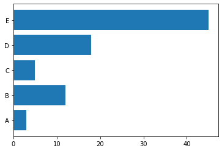

```python
# libraries
import numpy as np
import matplotlib.pyplot as plt

# Make fake dataset
height = [3, 12, 5, 18, 45]
bars = ('A', 'B', 'C', 'D', 'E')
y_pos = np.arange(len(bars))

# Create horizontal bars
plt.barh(y_pos, height)

# Create names on the y-axis
plt.yticks(y_pos, bars)

# Show graphic
plt.show()
```

```python
puchar_domow = {
    "Slytherin": {
        "Obrona przed Czarną Magią": 100,
        "Eliksiry" : 200,
        "Transmutacja": 150,
        "Zielarstwo": 50
     },
     "Gryffindor":{
        "Obrona przed Czarną Magią": 120,
        "Eliksiry" : 180,
        "Transmutacja": 300,
        "Zielarstwo": 120
     },
     "Ravenclaw":
     {
        "Obrona przed Czarną Magią": 140,
        "Eliksiry" : 120,
        "Transmutacja": 130,
        "Zielarstwo": 150
     },
     "Hufflepuff":
     {
        "Obrona przed Czarną Magią": 120,
        "Eliksiry" : 120,
        "Transmutacja": 120,
        "Zielarstwo": 120
     }
}
```

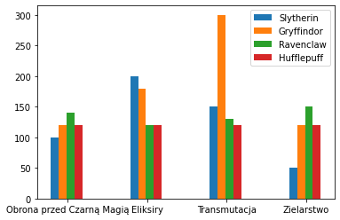

```python
import matplotlib.pyplot as plt
import numpy as np

barWidth = 0.3

for index, dom in enumerate(puchar_domow):
  plt.bar(
      3*np.arange(len(list(puchar_domow[dom].keys())))+(index*barWidth), #musimy przesunąć kolumny tak by na siebie nie nachodziły
      list(puchar_domow[dom].values()),
      width = barWidth,
      label=str(dom))

plt.xticks([0.5, 3.5, 6.5, 9.5], list(puchar_domow['Slytherin'].keys()))
plt.legend()
plt.show()
```

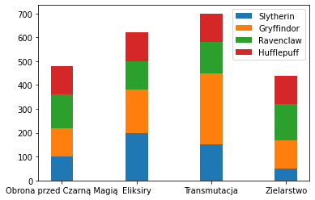

```python
import matplotlib.pyplot as plt
import numpy as np

barWidth = 0.3

temp = []
temp.append(np.zeros(4))
for index, dom in enumerate(puchar_domow):
  if index == 0:
    continue
  temp.append(list(puchar_domow[list(puchar_domow.keys())[index-1]].values()))

sum_temp = np.zeros(4)
for index, dom in enumerate(puchar_domow):
  sum_temp += temp[index]
  plt.bar(
      list(puchar_domow[dom].keys()),
      list(puchar_domow[dom].values()),
      width = barWidth,
      label=str(dom),
      bottom=sum_temp) #musimy podać co będzie dołem kolejnych kolumn, żeby je skleić
plt.legend()
plt.show()
```

Bardzo popularnym wykresem kolumnowym jest histogram. Histogram to nic innego jak wizualizacja rozkładu jakiejś cechy.

```
plt.hist(x, bins=None)
```

> **Gdzie:**
> - x - lista danych na podstawie, której chcemy wygenerować histogram
> - bins - na ile kolumn chcemy podzielić nasz histogram, domyślnie równa się liczbie unikatowych danych podanych w x. Może być liczbą, albo sekwencją liczb od których uwzględniamy kolejne kolumny

Wygenerujmy dane z rozkładu normalnego i wykreślmy ich histogram.

Źródło: https://matplotlib.org/3.1.1/gallery/pyplots/pyplot_text.html#sphx-glr-gallery-pyplots-pyplot-text-py

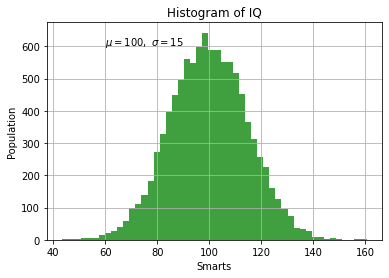

```python
import numpy as np
import matplotlib.pyplot as plt

# Fixing random state for reproducibility
np.random.seed(19680801)

mu, sigma = 100, 15
x = mu + sigma * np.random.randn(10000)

# the histogram of the data
n, bins, patches = plt.hist(x, 50, facecolor='g', alpha=0.75)


plt.xlabel('Smarts')
plt.ylabel('Population')
plt.title('Histogram of IQ')
plt.text(60, 602.5, r'$\mu=100,\ \sigma=15$')
plt.grid(True)
plt.show()
```

Jeżeli zamiast liczby w populacji interesuje nas prawdopodobieństwo wystąpienia danej kolumny histogramu w metodzie ustawiamy pole **density=True**.

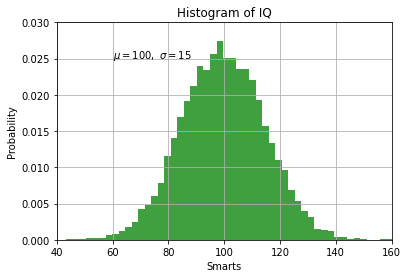

```python
import numpy as np
import matplotlib.pyplot as plt

# Fixing random state for reproducibility
np.random.seed(19680801)

mu, sigma = 100, 15
x = mu + sigma * np.random.randn(10000)

# the histogram of the data
n, bins, patches = plt.hist(x, 50, density=True, facecolor='g', alpha=0.75)


plt.xlabel('Smarts')
plt.ylabel('Probability')
plt.title('Histogram of IQ')
plt.text(60, .025, r'$\mu=100,\ \sigma=15$')
plt.xlim(40, 160)
plt.ylim(0, 0.03)
plt.grid(True)
plt.show()
```

Do generowania histogramu dwuwymiarowego stosujemy polecenie

```
plt.hist2d(x, y, bins=10, density=False)
```

> **Gdzie:**
> - x, y - wartości na osiach X,Y
> - bins - analogicznie do histogramu jednowymiarowego
> - density - analogicznie do histogramu jednowymiarowego

Utworzony wykres jest heat mapą danych

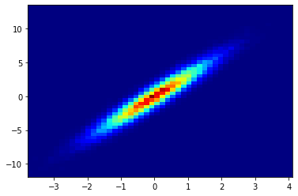

```python
import matplotlib.pyplot as plt
import numpy as np

# create data
x = np.random.normal(size=50000)
y = x * 3 + np.random.normal(size=50000)

# Big bins
plt.hist2d(x, y, bins=(50, 50), cmap=plt.cm.jet)
plt.show()
```

## 5. Piecharts - wykresy kołowe

Dotarliśmy do ostatniego kręgu piekła jeżeli chodzi o wizualizację danych. Wykresy kołowe owiane złą sprawą są z reguły niepotrzebne, a nasze dane możemy przedstawić w innej, lepszej formie. Jeżeli jednak uprzemy się na nie, je również można zrealizować w matplotlib.

[figure not shown]

[figure not shown]

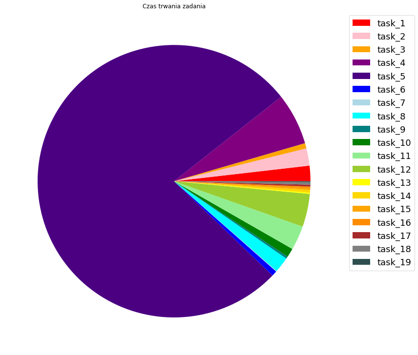

```python
import matplotlib.pyplot as plt

tasks = 'task_1', 'task_2', 'task_3', 'task_4', \
         'task_5', 'task_6', 'task_7', 'task_8', \
         'task_9', 'task_10', 'task_11', 'task_12', \
         'task_13', 'task_14', 'task_15', 'task_16', \
         'task_17', 'task_18', 'task_19'

time =[0.722539930138737,
     0.28336817817762494 + 0.5273803339805454,
     0.1135483211837709 + 0.13343579485081136,
     0.8881094930693507 + 0.3978329210076481 + 0.34098400291986763 + 0.4007001109421253 + 0.3937181669753045,
     3.1206228479277343 + 4.390893992036581 + 4.731932940194383 + 3.0876565920189023 + 15.17197903408669,
     0.052445481065660715 + 0.019446991849690676 + 0.019331110874190927 + 0.09747512708418071 + 0.060720112873241305,
     0.029143241932615638,
     0.7307675471529365,
     0.10479382984340191,
     0.4169424350839108,
     1.1366547809448093,
     1.5477838290389627,
     0.05833269190043211,
     0.12475891201756895,
     0.08382681896910071,
     0.0744338259100914,
     0.0875642818864435,
     0.11377762793563306,
     0.04675672412849963]

colors = ['red',
          'pink',
          'orange',
          'purple',
          'indigo',
          'blue',
          'lightblue',
          'cyan',
          'teal',
          'green',
          'lightgreen',
          'yellowgreen',
          'yellow',
          'gold',
          'orange',
          'darkorange',
          'brown',
          'gray',
          'darkslategray']

plt.figure(figsize=(15,  10))

patches = plt.pie(time,
                  colors=colors,
                  radius=1,
                  )

plt.legend(tasks, bbox_to_anchor=(1,1),
           fontsize=18)
plt.tight_layout()
plt.title("Czas trwania zadania")
plt.show()
```

Jedyną informację jaką jesteśmy w stanie wyciągnąć z naszego wykresu jest to, że istnieje jedno zadanie, którego czas trwania stanowi ok. 75% całego czasu. Z wykresu nie jesteśmy w stanie jednak wyczytać ile trwa poszczególne zadanie (możemy dodać tę informację, ale przy dużej liczbie małych fragmentów, będzie to nieczytelne). Dlatego tego typu wykresy mają tylko sens, przy małej liczbie unikatowych kategorii, na które chcemy dzielić nasze dane przy ich wizualizacji.

By poczytać więcej na ten temat zachęcam do lektury:

> https://www.businessinsider.com/pie-charts-are-the-worst-2013-6?IR=T

Popularną alternatywą dla wykresu kołowego jest wykres kołowy z wcięciem w środku, tzw. pączek. By go zrobić należy do wykresu dodać białe koło i upozycjonować je na środku wykresu kołowego.

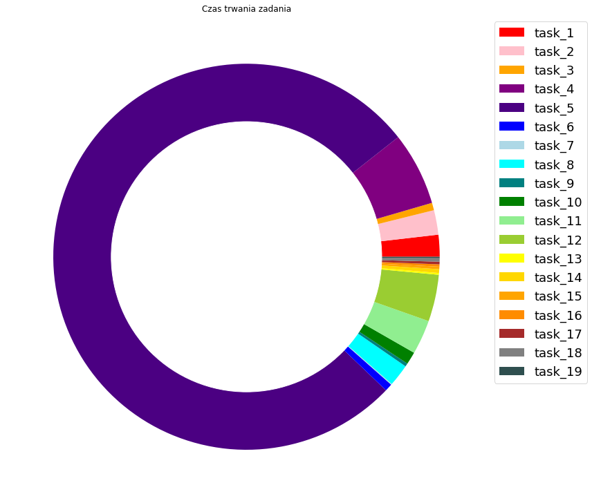

```python
import matplotlib.pyplot as plt

tasks = 'task_1', 'task_2', 'task_3', 'task_4', \
         'task_5', 'task_6', 'task_7', 'task_8', \
         'task_9', 'task_10', 'task_11', 'task_12', \
         'task_13', 'task_14', 'task_15', 'task_16', \
         'task_17', 'task_18', 'task_19'

time =[0.722539930138737,
     0.28336817817762494 + 0.5273803339805454,
     0.1135483211837709 + 0.13343579485081136,
     0.8881094930693507 + 0.3978329210076481 + 0.34098400291986763 + 0.4007001109421253 + 0.3937181669753045,
     3.1206228479277343 + 4.390893992036581 + 4.731932940194383 + 3.0876565920189023 + 15.17197903408669,
     0.052445481065660715 + 0.019446991849690676 + 0.019331110874190927 + 0.09747512708418071 + 0.060720112873241305,
     0.029143241932615638,
     0.7307675471529365,
     0.10479382984340191,
     0.4169424350839108,
     1.1366547809448093,
     1.5477838290389627,
     0.05833269190043211,
     0.12475891201756895,
     0.08382681896910071,
     0.0744338259100914,
     0.0875642818864435,
     0.11377762793563306,
     0.04675672412849963]

colors = ['red',
          'pink',
          'orange',
          'purple',
          'indigo',
          'blue',
          'lightblue',
          'cyan',
          'teal',
          'green',
          'lightgreen',
          'yellowgreen',
          'yellow',
          'gold',
          'orange',
          'darkorange',
          'brown',
          'gray',
          'darkslategray']

plt.figure(figsize=(15,  10))

patches = plt.pie(time,
                  colors=colors,
                  radius=1,
                  )

plt.legend(tasks, bbox_to_anchor=(1,1),
           fontsize=18)
plt.tight_layout()
plt.title("Czas trwania zadania")

# dodaj koło na środku
my_circle=plt.Circle( (0,0), 0.7, color='white')
p=plt.gcf()
p.gca().add_artist(my_circle)


plt.show()
```

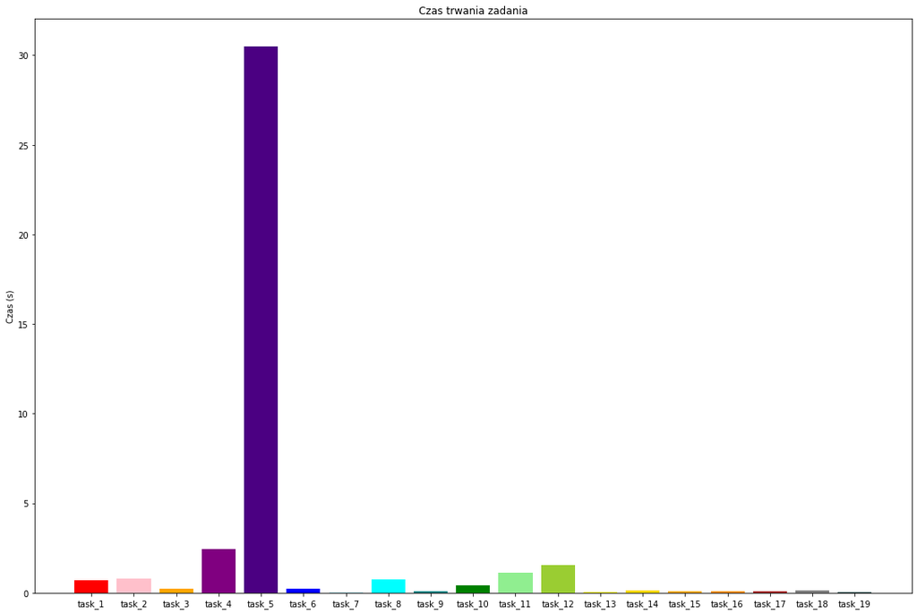

```python
import matplotlib.pyplot as plt

tasks = 'task_1', 'task_2', 'task_3', 'task_4', \
         'task_5', 'task_6', 'task_7', 'task_8', \
         'task_9', 'task_10', 'task_11', 'task_12', \
         'task_13', 'task_14', 'task_15', 'task_16', \
         'task_17', 'task_18', 'task_19'

time =[0.722539930138737,
     0.28336817817762494 + 0.5273803339805454,
     0.1135483211837709 + 0.13343579485081136,
     0.8881094930693507 + 0.3978329210076481 + 0.34098400291986763 + 0.4007001109421253 + 0.3937181669753045,
     3.1206228479277343 + 4.390893992036581 + 4.731932940194383 + 3.0876565920189023 + 15.17197903408669,
     0.052445481065660715 + 0.019446991849690676 + 0.019331110874190927 + 0.09747512708418071 + 0.060720112873241305,
     0.029143241932615638,
     0.7307675471529365,
     0.10479382984340191,
     0.4169424350839108,
     1.1366547809448093,
     1.5477838290389627,
     0.05833269190043211,
     0.12475891201756895,
     0.08382681896910071,
     0.0744338259100914,
     0.0875642818864435,
     0.11377762793563306,
     0.04675672412849963]

colors = ['red',
          'pink',
          'orange',
          'purple',
          'indigo',
          'blue',
          'lightblue',
          'cyan',
          'teal',
          'green',
          'lightgreen',
          'yellowgreen',
          'yellow',
          'gold',
          'orange',
          'darkorange',
          'brown',
          'gray',
          'darkslategray']

plt.figure(figsize=(15,  10))

plt.bar(tasks, time, color=colors)
plt.tight_layout()
plt.title("Czas trwania zadania")
plt.ylabel("Czas (s)")
plt.show()
```

Od razu lepiej. Dla lepszej czytelności możemy zmienić skalę w której wyświetlamy nasze wykresy. Służą do tego polecenia

```
plt.xscale("skala")
```

dla osi X

```
plt.yscale("skala")
```

dla osi Y

Dopuszczalne wartości:

- 'linear' - skala liniowa
- 'log' - skala logarytmiczna
- 'symlog' - skala logarytmiczna, symetryczna
- 'logit' - skala logit

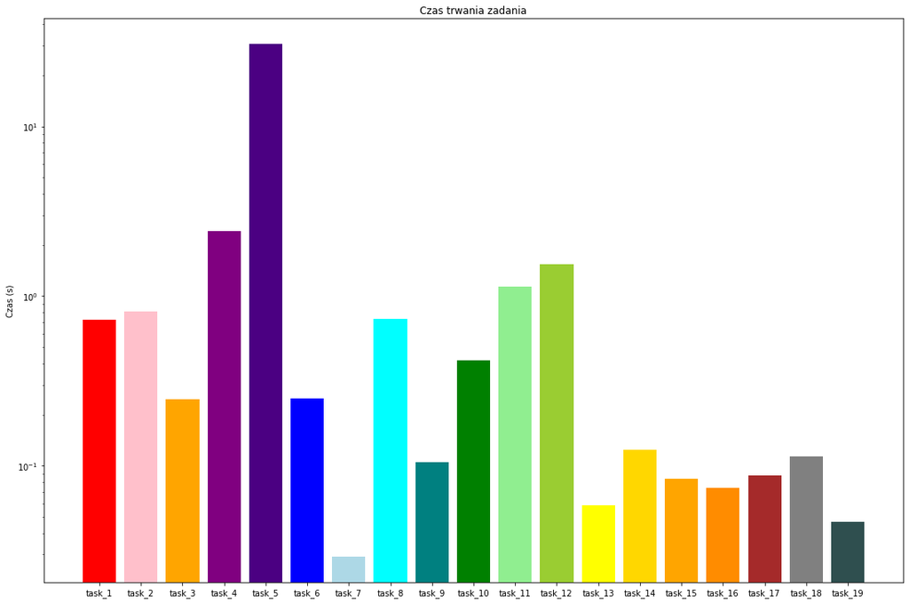

```python
import matplotlib.pyplot as plt

tasks = 'task_1', 'task_2', 'task_3', 'task_4', \
         'task_5', 'task_6', 'task_7', 'task_8', \
         'task_9', 'task_10', 'task_11', 'task_12', \
         'task_13', 'task_14', 'task_15', 'task_16', \
         'task_17', 'task_18', 'task_19'

time =[0.722539930138737,
     0.28336817817762494 + 0.5273803339805454,
     0.1135483211837709 + 0.13343579485081136,
     0.8881094930693507 + 0.3978329210076481 + 0.34098400291986763 + 0.4007001109421253 + 0.3937181669753045,
     3.1206228479277343 + 4.390893992036581 + 4.731932940194383 + 3.0876565920189023 + 15.17197903408669,
     0.052445481065660715 + 0.019446991849690676 + 0.019331110874190927 + 0.09747512708418071 + 0.060720112873241305,
     0.029143241932615638,
     0.7307675471529365,
     0.10479382984340191,
     0.4169424350839108,
     1.1366547809448093,
     1.5477838290389627,
     0.05833269190043211,
     0.12475891201756895,
     0.08382681896910071,
     0.0744338259100914,
     0.0875642818864435,
     0.11377762793563306,
     0.04675672412849963]

colors = ['red',
          'pink',
          'orange',
          'purple',
          'indigo',
          'blue',
          'lightblue',
          'cyan',
          'teal',
          'green',
          'lightgreen',
          'yellowgreen',
          'yellow',
          'gold',
          'orange',
          'darkorange',
          'brown',
          'gray',
          'darkslategray']

plt.figure(figsize=(15,  10))

plt.bar(tasks, time, color=colors)
plt.tight_layout()
plt.title("Czas trwania zadania")
plt.ylabel("Czas (s)")
plt.yscale("log")
plt.show()
```

Jak widać mając te same dane, w zależności od tego co chcemy przekazać użyjemy różnych metod do ich wizualizacji. Bardzo ważną częścią pracy z danymi jest umiejętny dobór narzędzi do wizualizacji danych. Ludzie są wzrokowcami, często prawidłowe dane, przedstawione w nieprawidłowy sposób prowadzą do niewłaściwych wniosków.

Polecam poczytać o 5 rzeczach, na które warto zwrócić uwagę analizując wykresy

https://venngage.com/blog/misleading-graphs/

## 6. Polar - wykresy liczb urojonych

Do wykresów liczb zespolonych istnieje specjalny wykres zwany polar.

```
plt.polar(theta, r)
```

> **Gdzie:**
> - theta - lista kątów
> - r - lista promieni

W konwencji tej 0 stopni oznacza liczbę rzeczywistą pozytywną, 180 stopni liczbę rzeczywistą negatywną, 90 stopni liczbę urojoną pozytywną, a 270 stopni liczbę urojoną ujemną. Wszystkie pozostałe stopnie to mieszanka liczb urojonych i liczb rzeczywistych czyli liczby zespolone.

> Źródło: https://www.geeksforgeeks.org/plotting-polar-curves-in-python/

### Kardioida (wykres sercowy)

$r = a + a \cos{\theta} $

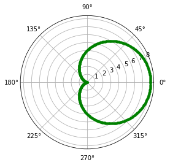

```python
import numpy as np
import matplotlib.pyplot as plt
import math


# setting the axes
# projection as polar
plt.axes(projection = 'polar')

# setting the length of
# axis of cardioid
a=4

# creating an array
# containing the radian values
rads = np.arange(0, (2 * np.pi), 0.01)

# plotting the cardioid
for rad in rads:
    r = a + (a*np.cos(rad))
    plt.polar(rad,r,'g.')

# display the polar plot
plt.show()
```

### Spirala Archimedesa

$ r = \theta$

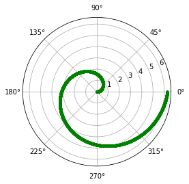

```python
import numpy as np
import matplotlib.pyplot as plt


# setting the axes
# projection as polar
plt.axes(projection = 'polar')

# creating an array
# containing the radian values
rads = np.arange(0, 2 * np.pi, 0.001)

# plotting the spiral
for rad in rads:
    r = rad
    plt.polar(rad, r, 'g.')

# display the polar plot
plt.show()
```

### Krzywa róży

$r = a \cos({n \theta})$

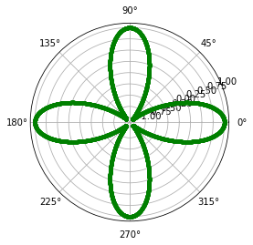

```python
import numpy as np
import matplotlib.pyplot as plt


# setting the axes
# projection as polar
plt.axes(projection='polar')

# setting the length
# and number of petals
a = 1
n = 4

# creating an array
# containing the radian values
rads = np.arange(0, 2 * np.pi, 0.001)

# plotting the rose
for rad in rads:
    r = a * np.cos(n*rad)
    plt.polar(rad, r, 'g.')

# display the polar plot
plt.show()
```

## 7. Obsługa obrazów - PIL

Poza generowaniem własnych wykresów biblioteka matplotlib umożliwia wczytywanie i wyświetlanie obrazów.

Odpowiednio:

```
plt.imread(fname, format=None)
```

> **Gdzie:**
> - fname - ścieżka do pliku na dysku, sama nazwa pliku jeżeli znajduje się w tym samym folderze co plik pythona, który uruchamiamy
> - format - format pliku, jeżeli nie jest sprecyzowany, domyślnie próbuje otworzyć plik w formatowaniu PNG

```
plt.imshow(X, cmap=None)
```

> **Gdzie:**
> - X - obiekt PIL lub tablica o określonych rozmiarach:
>   - (M, N)
>   - (M, N, 3): obraz RGB, wartości rzeczywiste z zakresu 0-1, lub całkowite z zakresu 0-255
>   - (M, N, 4): jak wyżej, z uwzględnieniem kanału przezroczystości alpha
- cmap - paleta kolorów, dla obrazów czarnobiałym warto zdefiniować odpowiednią paletę kolorów

Matplotlib posiada wiele palet kolorystycznych, poniżej znajduje się ich lista:

> https://matplotlib.org/examples/color/colormaps_reference.html

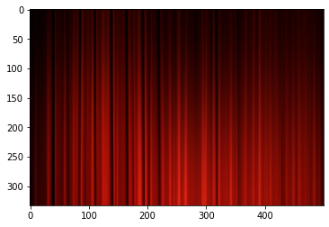

```python
import matplotlib.pyplot as plt

from google.colab import drive #polecenia potrzebne tylko w arkuszu Google by załadować zdjęcia z dysku Google, nie używać u siebie

drive.mount('/content/drive')

filter_img = plt.imread('/content/drive/My Drive/Warsztaty/filter.jpg')
plt.imshow(filter_img)
```